# 2장. 분류 분석(2)

```r
# credit card
credit <- read.csv('german_credit.csv')
credit$Creditability <- as.factor(credit$Creditability)

set.seed(1)
idx <- sample(1:nrow(credit),nrow(credit)*0.7,replace=F)
train <- credit[idx,]
test <- credit[-idx,]

# iris
data(iris)

set.seed(1)
idx <- sample(1:nrow(iris),nrow(iris)*0.7,replace=F)
train.iris <- iris[idx,]
test.iris <- iris[-idx,]
```

### 4절. SVM(Support Vector Machine) (e1071 패키지)

#### 1. 작동 원리

여러 경계 중 가장 큰 폭을 가진 경계를 찾아 분류/회귀

#### 2. R을 이용한 SVM 분석

- svm(formula, data, kernel, gamma, cost,…)
  - kernel : 훈련과 예측에 사용되는 커널 (‘radial’,‘linear’,‘polynomial’,‘sigmoid’)
  - gamma : 초평면의 기울기 (default = 1/p)
  - cost : 과적합을 막는 정도 (default = 1)
- **tune.svm(formula, data, kernel, gamma, cost,…)\**

  SVM 모형에서 최적의 파라미터 값을 찾아내기 위해 사용되는 함수

```r
library(e1071)
tune.svm(Creditability~.,
         data = credit,
         gamma = 10^(-6:-1),
         cost = 10^(1:2))
```

```
##
## Parameter tuning of 'svm':
##
## - sampling method: 10-fold cross validation
##
## - best parameters:
##  gamma cost
##   0.01   10
##
## - best performance: 0.236
```

```r
svm.model <- svm(Creditability~.,
                 data = train,
                 kernel='radial',
                 gamma=0.01,
                 cost=10)
summary(svm.model)
```

```
##
## Call:
## svm(formula = Creditability ~ ., data = train, kernel = "radial",
##     gamma = 0.01, cost = 10)
##
##
## Parameters:
##    SVM-Type:  C-classification
##  SVM-Kernel:  radial
##        cost:  10
##
## Number of Support Vectors:  383
##
##  ( 179 204 )
##
##
## Number of Classes:  2
##
## Levels:
##  0 1
```

```r
pred.svm <- predict(svm.model, test, type='class')

# 오분류표
library(caret)
confusionMatrix(data = pred.svm, reference = test[,1], positive = '1')
```

```
## Confusion Matrix and Statistics
##
##           Reference
## Prediction   0   1
##          0  43  33
##          1  41 183
##
##                Accuracy : 0.7533
##                  95% CI : (0.7005, 0.8011)
##     No Information Rate : 0.72
##     P-Value [Acc > NIR] : 0.1100
##
##                   Kappa : 0.3699
##
##  Mcnemar's Test P-Value : 0.4158
##
##             Sensitivity : 0.8472
##             Specificity : 0.5119
##          Pos Pred Value : 0.8170
##          Neg Pred Value : 0.5658
##              Prevalence : 0.7200
##          Detection Rate : 0.6100
##    Detection Prevalence : 0.7467
##       Balanced Accuracy : 0.6796
##
##        'Positive' Class : 1
##
```

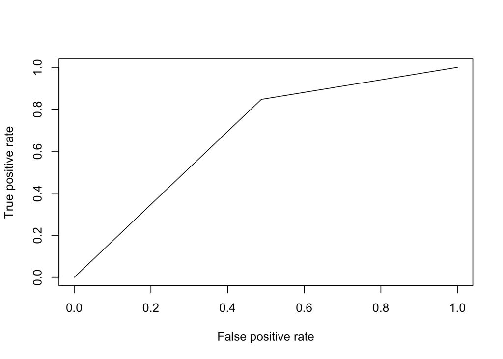

```r
# ROC 그래프와 AUC
library(ROCR)
pred.svm.roc <- prediction(as.numeric(pred.svm), as.numeric(test[,1]))
plot(performance(pred.svm.roc,'tpr','fpr'))
```

```r
performance(pred.svm.roc,'auc')@y.values
```

```
## [[1]]
## [1] 0.6795635
```

### 5절. 나이브 베이즈 분류(Naive Bayes Classification) (e1071 패키지)

#### 1. Bayes theorem

: 두 확률 변수의 사전 확률과 사후 확률 사이의 관계를 나타내는 정리

$$P(A|B) = \frac{P(B\cap A)}{P(B)} = \frac{P(A)P(B|A)}{P(B)} =
\frac{P(A)P(B|A)}{P(A)P(B|A)+P(A^c)P(B|A^c)}$$

#### 2. 나이브 베이즈 분류

: 속성값에 대해 다른 속성이 독립적이라 전제했을 때 해당 속성 값이 클래스 분류에 미치는 영향을 측정

#### 3. R을 이용한 나이브 베이즈 분류 분석

- naiveBayes(formula, data, laplace=0,…)
  - laplace : 라플라스 보정 여부

```r
library(e1071)
nb.model <- naiveBayes(Creditability~.,
                       data = train,
                       laplace = 0)
nb.model
```

```
##
## Naive Bayes Classifier for Discrete Predictors
##
## Call:
## naiveBayes.default(x = X, y = Y, laplace = laplace)
##
## A-priori probabilities:
## Y
##         0         1
## 0.3085714 0.6914286
##
## Conditional probabilities:
##    Account.Balance
## Y       [,1]     [,2]
##   0 1.875000 1.046867
##   1 2.847107 1.228278
##
##    Duration.of.Credit..month.
## Y       [,1]     [,2]
##   0 25.37037 13.71341
##   1 18.81612 10.84529
##
##    Payment.Status.of.Previous.Credit
## Y       [,1]     [,2]
##   0 2.171296 1.113682
##   1 2.768595 1.067187
##
##    Purpose
## Y       [,1]     [,2]
##   0 2.763889 2.891011
##   1 2.745868 2.750397
##
##    Credit.Amount
## Y       [,1]     [,2]
##   0 3954.116 3597.398
##   1 2952.895 2377.053
##
##    Value.Savings.Stocks
## Y      [,1]     [,2]
##   0 1.62963 1.247081
```

[output cut: 56 more lines]

```
##
##    No.of.dependents
## Y       [,1]      [,2]
##   0 1.138889 0.3466339
##   1 1.163223 0.3699515
##
##    Telephone
## Y       [,1]      [,2]
##   0 1.356481 0.4800723
##   1 1.400826 0.4905730
##
##    Foreign.Worker
## Y       [,1]      [,2]
##   0 1.018519 0.1351300
##   1 1.053719 0.2256956
```

```r
pred.nb <- predict(nb.model, test[,-1],type = 'class')

# 오분류표
library(caret)
confusionMatrix(data = pred.nb, reference = test[,1], positive = '1')
```

```
## Confusion Matrix and Statistics
##
##           Reference
## Prediction   0   1
##          0  53  49
##          1  31 167
##
##                Accuracy : 0.7333
##                  95% CI : (0.6795, 0.7825)
##     No Information Rate : 0.72
##     P-Value [Acc > NIR] : 0.32910
##
##                   Kappa : 0.3793
##
##  Mcnemar's Test P-Value : 0.05735
##
##             Sensitivity : 0.7731
##             Specificity : 0.6310
##          Pos Pred Value : 0.8434
##          Neg Pred Value : 0.5196
##              Prevalence : 0.7200
##          Detection Rate : 0.5567
##    Detection Prevalence : 0.6600
##       Balanced Accuracy : 0.7021
##
##        'Positive' Class : 1
##
```

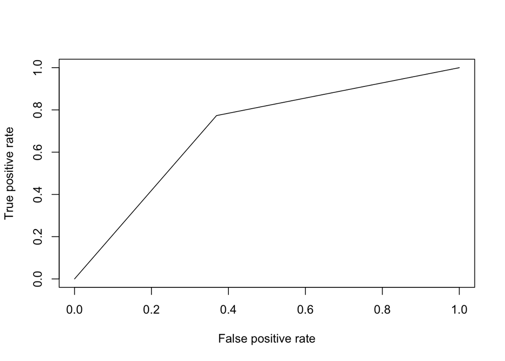

```r
# ROC 그래프와 AUC
pred.nb.roc <- prediction(as.numeric(pred.nb),as.numeric(test[,1]))
library(ROCR)
plot(performance(pred.nb.roc,'tpr','fpr'))
```

```r
performance(pred.nb.roc,'auc')@y.values
```

```
## [[1]]
## [1] 0.7020503
```

### 6절. K-NN(K-Nearest Neighbor) (class 패키지)

#### 1. K-NN 알고리즘의 원리

#### 2. K의 선택

일반적으로 **훈련 데이터 개수의 제곱근**으로 설정

#### 3. R을 이용한 K-NN 분석

- knn(train, test, cl, k,…)
  - cl : 훈련 데이터의 종속변수
  - k : 이웃의 개수

```r
library(class)
knn.3 <- knn(train[,-1], test[,-1],train[,1],k=3)
knn.26<- knn(train[,-1], test[,-1],train[,1],
             k=round(sqrt(nrow(train))))

library(caret)
confusionMatrix(knn.3, test$Creditability)
```

```
## Confusion Matrix and Statistics
##
##           Reference
## Prediction   0   1
##          0  21  52
##          1  63 164
##
##                Accuracy : 0.6167
##                  95% CI : (0.559, 0.672)
##     No Information Rate : 0.72
##     P-Value [Acc > NIR] : 1.0000
##
##                   Kappa : 0.0096
##
##  Mcnemar's Test P-Value : 0.3511
##
##             Sensitivity : 0.2500
##             Specificity : 0.7593
##          Pos Pred Value : 0.2877
##          Neg Pred Value : 0.7225
##              Prevalence : 0.2800
##          Detection Rate : 0.0700
##    Detection Prevalence : 0.2433
##       Balanced Accuracy : 0.5046
##
##        'Positive' Class : 0
##
```

```r
confusionMatrix(knn.26, test$Creditability)
```

```
## Confusion Matrix and Statistics
##
##           Reference
## Prediction   0   1
##          0   8  10
##          1  76 206
##
##                Accuracy : 0.7133
##                  95% CI : (0.6586, 0.7638)
##     No Information Rate : 0.72
##     P-Value [Acc > NIR] : 0.6292
##
##                   Kappa : 0.0644
##
##  Mcnemar's Test P-Value : 2.398e-12
##
##             Sensitivity : 0.09524
##             Specificity : 0.95370
##          Pos Pred Value : 0.44444
##          Neg Pred Value : 0.73050
##              Prevalence : 0.28000
##          Detection Rate : 0.02667
##    Detection Prevalence : 0.06000
##       Balanced Accuracy : 0.52447
##
##        'Positive' Class : 0
##
```

```r
# 최적의 k
result <- numeric()
k=1:28
for (i in k) {
  pred <- knn(train[,-1], test[,-1],train[,1],k=i)
  t <- table(pred, test$Creditability)
  result[i] <- (t[1,1]+t[2,2])/sum(t)
}
result
```

```
##  [1] 0.5766667 0.5866667 0.6166667 0.6466667 0.6333333 0.6466667 0.6533333
##  [8] 0.6500000 0.6566667 0.6600000 0.6666667 0.6700000 0.6800000 0.6733333
## [15] 0.7033333 0.6866667 0.7066667 0.7100000 0.7200000 0.7000000 0.7066667
## [22] 0.7233333 0.7166667 0.7133333 0.7166667 0.7033333 0.7033333 0.7033333
```

```r
which(result==max(result))
```

```
## [1] 22
```

### 7절. 인공신경망 모형(Artificial Neural Network) (nnet 패키지)

#### 1. 특징

입력 링크에서 여러 신호를 받아서 새로운 활성화 수준을 계산하고 출력 링크로 출력 신호를 보냄

활성화 함수를 이용해 출력을 결정하며 입력신호의 가중치 합을 계산하여 임계값 비교  
-> -1 or 1 출력

- 뉴런의 활성화 함수
  - 계단 함수
  - 부호 함수
  - 시그모이드 함수
  - relu 함수
  - softmax 함수

#### 2. R을 이용한 인공신경망 분석

- nnet(formula, data, size, maxit, decay=5e-04,…)
  - size : hidden node의 개수
  - maxit : 학습 반복횟수, 반복 중 가장 좋은 모델을 선정
  - decay : 가중치 감소의 모수
- **garson(mod_in) (NeuralNetTools 패키지)\**

  모델의 변수 중요도 파악
  - mod_in : 생성된 인공신경망 모델

```r
library(nnet)
set.seed(1)
nn.model <- nnet(Creditability~.,
                 data = train,
                 size=2,
                 maxit=200,
                 decay=5e-04)
summary(nn.model)
```

```
## a 20-2-1 network with 45 weights
## options were - entropy fitting  decay=5e-04
##   b->h1  i1->h1  i2->h1  i3->h1  i4->h1  i5->h1  i6->h1  i7->h1  i8->h1  i9->h1
##    1.15   -4.89    5.76   -0.85    1.58    0.14   -3.78    0.25    1.44   -0.17
## i10->h1 i11->h1 i12->h1 i13->h1 i14->h1 i15->h1 i16->h1 i17->h1 i18->h1 i19->h1
##   -2.14    2.49    9.85   -4.93   -7.67    1.49    5.05    0.47    7.29   -3.24
## i20->h1
##   -1.31
##   b->h2  i1->h2  i2->h2  i3->h2  i4->h2  i5->h2  i6->h2  i7->h2  i8->h2  i9->h2
##    0.53    9.74    3.99   12.25   -0.03   -0.03   -2.54    1.03   -5.22    9.24
## i10->h2 i11->h2 i12->h2 i13->h2 i14->h2 i15->h2 i16->h2 i17->h2 i18->h2 i19->h2
##   -2.24    0.37   11.67    0.19   -4.81    0.37   -9.03   -0.65   11.56  -17.48
## i20->h2
##    0.18
##   b->o  h1->o  h2->o
##   2.18  -2.69   1.33
```

[figure not shown]

```r
# 변수중요도
#install.packages('NeuralNetTools')
library(NeuralNetTools)
garson(nn.model)
```

```r
pred.nn <- predict(nn.model, test[,-1], type = 'class')

# 오분류표
library(caret)
confusionMatrix(as.factor(pred.nn), test[,1],positive = '1')
```

```
## Confusion Matrix and Statistics
##
##           Reference
## Prediction   0   1
##          0  19  19
##          1  65 197
##
##                Accuracy : 0.72
##                  95% CI : (0.6655, 0.7701)
##     No Information Rate : 0.72
##     P-Value [Acc > NIR] : 0.5294
##
##                   Kappa : 0.166
##
##  Mcnemar's Test P-Value : 9.112e-07
##
##             Sensitivity : 0.9120
##             Specificity : 0.2262
##          Pos Pred Value : 0.7519
##          Neg Pred Value : 0.5000
##              Prevalence : 0.7200
##          Detection Rate : 0.6567
##    Detection Prevalence : 0.8733
##       Balanced Accuracy : 0.5691
##
##        'Positive' Class : 1
##
```

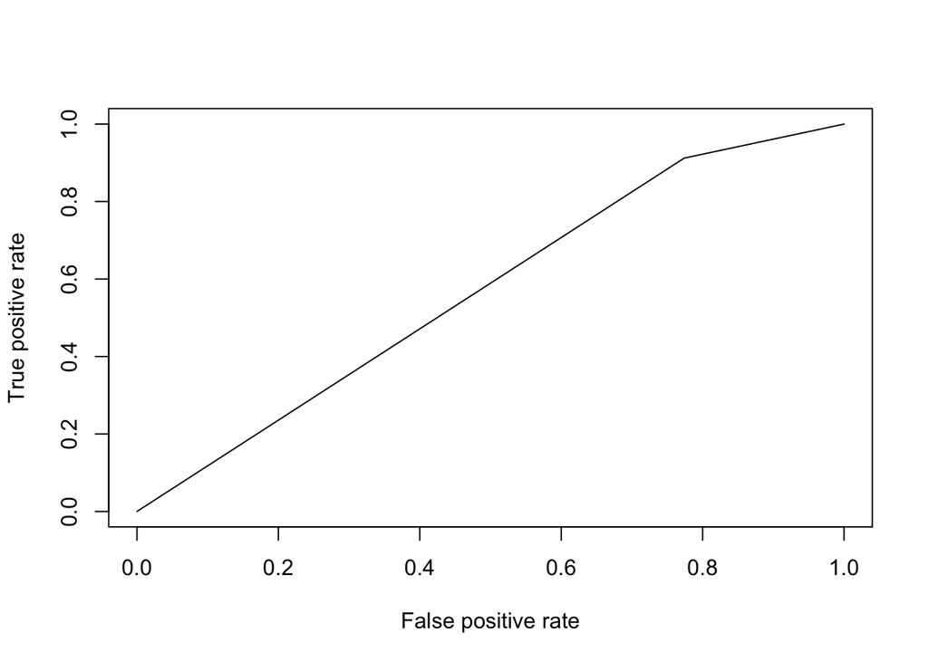

```r
# ROC그래프와 AUC
library(ROCR)
pred.nn.roc <- prediction(as.numeric(pred.nn), as.numeric(test[,1]))
plot(performance(pred.nn.roc,'tpr','fpr'))
```

```r
performance(pred.nn.roc,'auc')@y.values
```

```
## [[1]]
## [1] 0.5691138
```

- **neuralnet(formula, data, algorithm, threshold, hidden, stepmax,…) (neuralnet 패키지)\**

  탄력적 역전파가 사용되었고 인공신경망 중 빠른 알고리즘
  - algorithm : 사용할 알고리즘 지정 (‘backprop’,‘rprop+’,‘rprop-’,…)
  - threshold : 훈련중단 기준 (default = 0.01)
  - hidden : 은닉노드의 개수
  - stepmax : 인공 신경망 훈련 수행 최대 횟수

```r
#install.packages('neuralnet')
library(neuralnet)
library(caret)

data("infert")
set.seed(1)
in.part <- createDataPartition(infert$case,
                               times = 1,
                               p=0.7)
table(infert[in.part$Resample1,'case'])
```

```
##
##   0   1
## 119  55
```

```r
parts <- as.vector(in.part$Resample1)
train.infert <- infert[parts,]
test.infert <- infert[-parts,]

nn.model2 <- neuralnet(case~age+parity+induced+spontaneous,
                       data=train.infert,
                       hidden = c(2,2),
                       algorithm = 'rprop+',
                       threshold = 0.01,
                       stepmax = 1e+5)
plot(nn.model2)


# 오분류표
set.seed(2)
test.infert$nn.model2_pred.prob <- compute(nn.model2, covariate = test.infert[,c(2:4,6)])$net.result   # 오류가 있는듯
test.infert$nn.model2_pred <- ifelse(test.infert$nn.model2_pred.prob>0.5,1,0)
confusionMatrix(as.factor(test.infert$nn.model2_pred),as.factor(test.infert[,5]))
```

```
## Confusion Matrix and Statistics
##
##           Reference
## Prediction  0  1
##          0 37  9
##          1  9 19
##
##                Accuracy : 0.7568
##                  95% CI : (0.6431, 0.849)
##     No Information Rate : 0.6216
##     P-Value [Acc > NIR] : 0.009813
##
##                   Kappa : 0.4829
##
##  Mcnemar's Test P-Value : 1.000000
##
##             Sensitivity : 0.8043
##             Specificity : 0.6786
##          Pos Pred Value : 0.8043
##          Neg Pred Value : 0.6786
##              Prevalence : 0.6216
##          Detection Rate : 0.5000
##    Detection Prevalence : 0.6216
##       Balanced Accuracy : 0.7415
##
##        'Positive' Class : 0
##
```